# Using Data To Determine Which AFL Fans Jump On The Bandwagon

2019-07-15

# Introduction

This post is the first in a two-part series on AFL crowds. This analysis will be a thorough look at AFL crowd numbers over the last 20 years, and will aim to discover which team’s fans are the biggest bandwagon jumpers. *Bandwagon Jumpers* are those fans that are the loudest in the office or in your friendship group when things are going well, and the quietest when their team is losing. The analysis will use two questions to answer this:

1. Which team’s home attendance is affected more because of the previous week’s performance
   1. Here I will introduce three new metrics to measure this effect
2. Does a team’s betting odds affect home attendance

People all have their theories on which team’s fans are the worst offending bandwagoners; this analysis will try to answer it once and for all! Also, sefishly, I’m sick of people telling me that fans of my team - the Hawthorn Hawks (a team that has experienced tremendous success over the last 10 years) are the worst offenders.

## The Data

Data was collected from a few different online sources. The game and attendance data was sourced using the rvest package from the amazing [AFL Tables](https://afltables.com), while the betting data was sourced from the [Australian Sports Betting](http://www.aussportsbetting.com) website.

All the code and data for this project is available on [GitHub](https://github.com/JaseZiv/AFL-Crowd-Analytics). The [Tidyverse](https://www.tidyverse.org/) suite of packages features heavily throughout.

The data is current to round 16 of the 2019 season.

Over the last 20 years, the median (the 50% mark and a better measure than the average on skewed data) crowd to AFL games was 33,600. The data is positively skewed with a tail that extends out to 100,000.

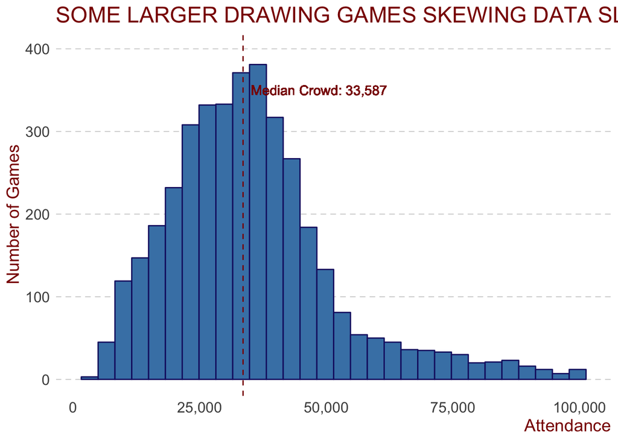

As expected for the AFL, the finals series at the end of the season draws larger crowds than the premiership (regular season for non-AFL fans) season. The median attendance for the premiership season is just over 33,000, while for finals it is over 58,000. The finals series are the flagship games for the AFL - they would hope these games would draw larger crowds.

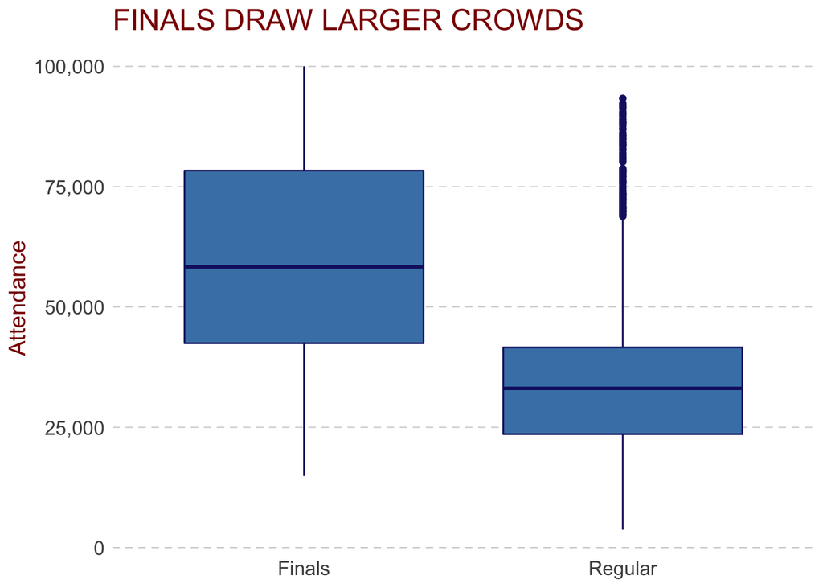

We can’t glean a lot from finals since they’re well patronised irrespective of who’s playing, so the rest of the analysis will focus on the premiership season.

The last 20 seasons have seen some peaks and throughs though, with median attendances ranging from just under 29,000 in 2012 to just over 36,800 in 2008. The low attendances in 2012-13 were no doubt fuelled by the introduction of the newest expansion teams - Gold Coast and Greater Western Sydney (GWS) - in regions that are traditionally not AFL strongholds. The last five years however have seen a rebound of sorts, as these clubs slowly build up fanbases (and in the case of GWS start to have some success).

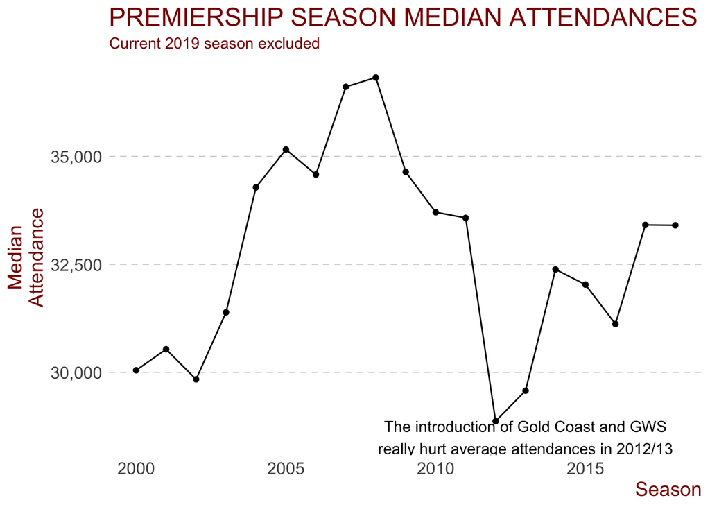

# Which teams draw larger attendances

So what about the age old question asked around the water cooler… who has more fans?

Well this post won’t be able to answer that question. What it can answer is which teams’s fans attend games in greater numbers?

There are seven teams that have had above average crowds since the 2000 season:

- Collingwood
- Essendon
- Richmond
- Adelaide
- Carlton
- West Coast
- Hawthorn

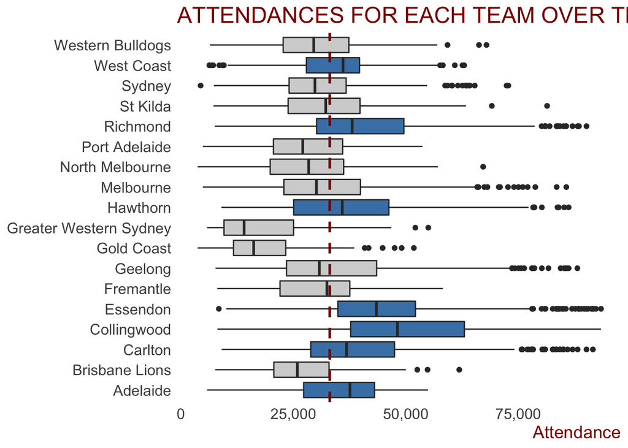

# Which team’s home attendance is affected more because of the previous week’s performance

To answer this question, we can look at the difference in attendance for each team the next game after a win or a loss. Three metrics have been created to help answer this question:

- Losing Impact on Attendance (LIoA)
- Winning Impact on Attendance (WIoA)
- Overall Performance Impact (OPI)

To create the LIoA and WIoA metrics, the median home attendance (regadless if the previous game was a a win or loss) was calculated for each team. To calculate the LIoA, the median home attendance after a loss was claculated and the percentage difference between this and the overall median home attendance became the measure. The WIoA was calculated in almost the same way, but the median home attandance after a win was used instead.

Finally, OPI is calculated as the difference between WIoA and LIoA.

A few things to note using this method:

1. Round one games have been excluded as the previous game was the last season and there’s too much noise using that
2. Only home games for each team have been used to calculate the metrics
3. With a p-value < 0.05, the team’s last result is a significant predictor

First thing we can do is visualise the data. Using boxplots to show the team’s distribution of home attendances for games both after a win and loss, we can see that there are what appear to be considerable differences for some teams. Where the line in the middle of the box (the median) differs noticably between a win or loss the previous week is an indication that that team’s supporters may be less inclined to attend their team’s games after a loss (or more inclined after a win).

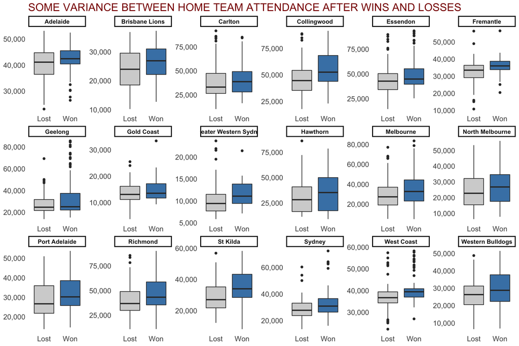

## Overall Performance Impact

| Team | Median Home Attendance | Attendance After Loss | Attendance After Win | LIoA | WIoA | OPI |
| --- | --- | --- | --- | --- | --- | --- |
| Adelaide | 41897.5 | 41095.0 | 42415.0 | -0.0192 | 0.0124 | 0.0316 |
| Brisbane Lions | 25403.0 | 23943.0 | 26872.0 | -0.0575 | 0.0578 | 0.1153 |
| Carlton | 35147.5 | 33115.5 | 38743.5 | -0.0578 | 0.1023 | 0.1601 |
| Collingwood | 48261.0 | 44607.0 | 52592.0 | -0.0757 | 0.0897 | 0.1654 |
| Essendon | 43947.0 | 42617.0 | 44736.0 | -0.0303 | 0.018 | 0.0483 |
| Fremantle | 34553.0 | 33539.5 | 36026.0 | -0.0293 | 0.0426 | 0.0719 |
| Geelong | 24857.0 | 24659.0 | 25078.0 | -0.008 | 0.0089 | 0.0169 |
| Gold Coast | 13247.5 | 13080.0 | 13528.0 | -0.0126 | 0.0212 | 0.0338 |
| Greater Western Sydney | 10069.5 | 9395.5 | 11071.5 | -0.0669 | 0.0995 | 0.1664 |
| Hawthorn | 31925.0 | 28152.5 | 35202.0 | -0.1182 | 0.1026 | 0.2208 |
| Melbourne | 28707.0 | 27266.0 | 32621.0 | -0.0502 | 0.1363 | 0.1865 |
| North Melbourne | 24062.0 | 22754.0 | 26763.0 | -0.0544 | 0.1123 | 0.1667 |
| Port Adelaide | 28206.0 | 26652.0 | 30197.0 | -0.0551 | 0.0706 | 0.1257 |
| Richmond | 39713.5 | 36821.0 | 43240.0 | -0.0728 | 0.0888 | 0.1616 |
| St Kilda | 30497.0 | 26974.0 | 33944.0 | -0.1155 | 0.113 | 0.2285 |
| Sydney | 29264.0 | 27715.5 | 30863.5 | -0.0529 | 0.0547 | 0.1076 |
| West Coast | 38029.0 | 36710.0 | 39436.0 | -0.0347 | 0.037 | 0.0717 |
| Western Bulldogs | 27818.5 | 26301.0 | 28769.0 | -0.0546 | 0.0342 | 0.0888 |

# Does a team’s betting odds affect home attendance?

To answer this question, betting data was collected from the [Australian Sports Betting](http://www.aussportsbetting.com) website.

Line data was available from 2013 onwards, so the crowd data for this question has been limited down to the last six seasons.

The opening game lines were used for the Home Team. Where the line was within +/- 6 points (1 goal), the game was deemed to be `Neutral`, meaning no one was the favourite. If the line was set above 6 points, then the Home Team was the `Favourite`. Lastly, if the line was -6 points, the Home Team was the `Underdog`. This has also been found to be a significant predictor, also with a p-value close to zero.

## Underdog Impact

When the home team is the underdog, what is the impact to their home attendance?

Hawthorn feature near the top of this list too… not a good sign.

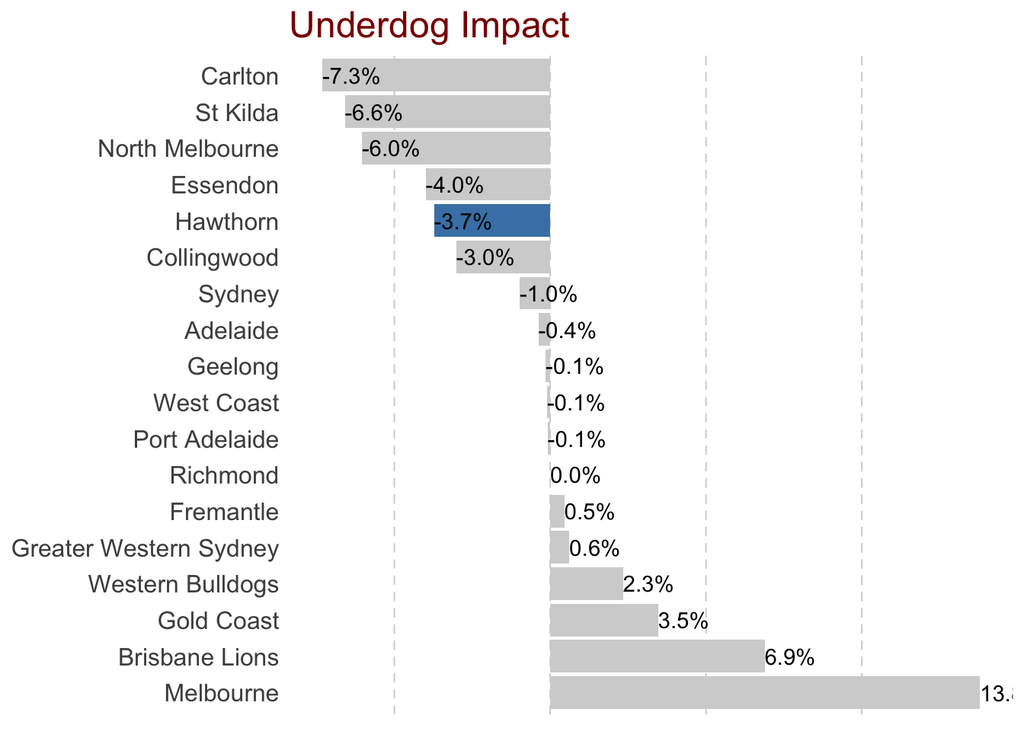

## Favourite Impact

Wow… Ok this doesn’t look great. Hawthorn’s median attendance when favourite is over 45% higher than their overall home attendance since 2013. Geelong’s, just over 40%, is also abnormally high.

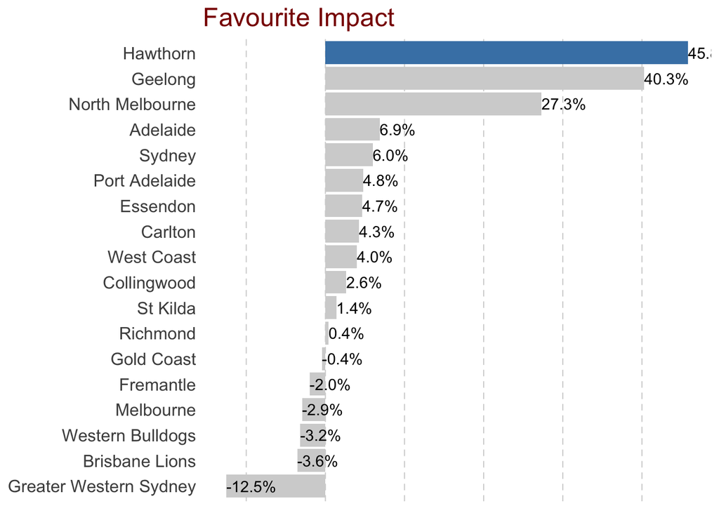

Well, that didn’t work out how I expected. Rather than busting the myth that Hawthorn fans are the biggest bandwagon jumpers in the league, I’ve actually added to the argument.

Stay tuned for part two of this series, where I will attempt to build a predictive model that predicts AFL attendances.

Feel free to leave any feedback / corrections / etc in the comments or get in [touch](https://www.linkedin.com/in/jason-zivkovic-4a0a1926/).